# **Deep Learning–Based Malaria Detection Using Convolutional Neural Networks**

### Artificial Intelligence • Computer Vision • Medical Image Analysis

**Author:** Shams Rahman, MD, PhD, MPH, MBA, CPH

**Project:** Deep Learning–Based Malaria Detection Using Convolutional Neural Networks

**Research Area:** Artificial Intelligence, Computer Vision, Medical Image Analysis, Global Health

**Date:** June 2026

## **Project Overview**

This project develops and evaluates multiple deep learning architectures for automated malaria detection using microscopic blood smear images. Multiple convolutional neural network (CNN) architectures, including baseline CNN, image augmentation, transfer learning, batch normalization, and advanced activation functions, are developed and compared to identify robust and interpretable models for binary image classification. Beyond model performance, the project demonstrates the application of artificial intelligence to healthcare through reproducible computational workflows, rigorous model evaluation, and clinically relevant performance metrics. Collectively, this work illustrates how deep learning can support disease detection, medical image analysis, and scalable healthcare applications.

> **Acknowledgment:** This project was completed as part of the Applied AI and Data Science Professional Program offered through MIT Professional Education. The implementation, experiments, analyses, visualizations, and documentation presented in this notebook are my own work. The malaria microscopy image dataset used in this project is publicly available and was not developed by MIT.

> **Reproducibility Note:** Deep learning model training involves stochastic initialization and randomized training processes. Consequently, repeated executions may produce small variations in performance metrics (typically limited to minor decimal differences) while leading to the same overall conclusions. Future versions of this project will incorporate fixed random seeds to ensure fully reproducible model training and identical results across executions.

**1. Problem Definition**

**2. Environment Setup**

- Import Required Libraries

**3. Data Loading and Dataset Preparation**

**4. Exploratory Data Analysis (EDA)**

- Dataset Verification
- Visual Exploration of Blood Smear Images
- Image Dimensions and Pixel Characteristics
- Class Distribution
- Mean Image Comparison
- HSV Color Space Exploration
- Gaussian Blur
- EDA Summary
- Observations and Insights

**5. Image Preprocessing**

- Image Normalization
- Label Encoding
- Data Shuffling
- Observations and Insights

**6. Baseline Convolutional Neural Network (CNN)**

- Baseline CNN Architecture
- Model Compilation
- Model Training
- Model Evaluation
- Observations and Insights

**7. Improved Convolutional Neural Network (CNN)**

- Improved CNN Architecture
- Model Compilation
- Model Training
- Model Evaluation
- Observations and Insights

**8. Batch Normalization + LeakyReLU CNN**

- Model Architecture
- Model Compilation
- Model Training
- Model Evaluation
- Observations and Insights

**9. Image Augmentation CNN**

- Image Augmentation
- Model Architecture
- Model Compilation
- Model Training
- Model Evaluation
- Observations and Insights

**10. Comparative Performance Analysis**

- Performance Comparison Table
- Accuracy Comparison
- Loss Comparison
- ROC Curve Comparison
- Model Ranking
- Observations and Insights

**11. Conclusion**

**12. Future Work**

**13. References**

# **How to Read This Notebook**

This notebook presents a complete deep learning workflow for automated malaria detection using microscopic blood smear images. The analysis is organized in a logical sequence, beginning with problem formulation and progressing through data exploration, model development, evaluation, and final recommendations.

Each major section is structured to answer three key questions:

1. **What are we doing?**  
   The objective and methodology introduce the purpose of the section and the analytical approach used.
2. **What did we find?**  
   Python code generates the results, including visualizations, performance metrics, and model outputs.
3. **Why does it matter?**  
   The *Results, Observations, and Discussion* summarize the findings, interpret their significance, and explain how they contribute to selecting the most appropriate deep learning model for malaria detection.

This structure is intended to create a clear, reproducible, and reader-friendly workflow while supporting both the milestone submission and the final capstone report.

# **1. Problem Definition**

## **Background**

Malaria is a life-threatening vector-borne infectious disease caused by *Plasmodium* parasites and transmitted through the bites of infected female *Anopheles* mosquitoes [1]. Despite significant advances in prevention and treatment, malaria remains one of the world's leading causes of infectious disease morbidity and mortality. According to the World Health Organization (WHO), there were an estimated **263 million malaria cases** and approximately **597,000 malaria-related deaths** worldwide in **2023**, with nearly **95% of all deaths occurring in the WHO African Region**. Children younger than five years accounted for approximately **76% of all malaria deaths**, emphasizing the substantial impact of the disease on vulnerable populations [2].

Accurate and timely diagnosis is essential for effective treatment, reducing disease severity, and limiting transmission. The laboratory reference standard for malaria diagnosis is microscopic examination of Giemsa-stained thick and thin blood smears, allowing direct visualization of malaria parasites within red blood cells, parasite quantification, and species identification [3]. However, microscopic diagnosis is labor-intensive, requires highly trained personnel, and is susceptible to inter-observer variability, particularly in resource-limited settings where experienced microscopists are scarce. These challenges have motivated increasing interest in artificial intelligence (AI)-based diagnostic tools capable of supporting automated image interpretation.

Recent advances in deep learning have demonstrated remarkable success in medical image analysis. Convolutional Neural Networks (CNNs) can automatically learn complex visual patterns directly from images without manual feature engineering, making them particularly suitable for classifying microscopic blood smear images. Automated malaria detection systems have the potential to improve diagnostic consistency, reduce laboratory workload, and support rapid clinical decision-making in endemic regions.

## **Study Objective**

The objective of this project is to develop and evaluate multiple deep learning models for the automated detection of malaria using microscopic blood smear images. Specifically, this study compares a baseline Convolutional Neural Network (CNN), a CNN incorporating image augmentation, and a transfer learning model to identify the approach that provides the highest classification performance and best generalization to previously unseen images.

## **Research Questions**

This project aims to address the following research questions:

- Can a baseline Convolutional Neural Network accurately distinguish parasitized blood cells from uninfected cells?
- Does image augmentation improve the model's ability to generalize to unseen microscopic images?
- Does transfer learning outperform a custom CNN architecture for malaria image classification?
- Which deep learning approach provides the best overall performance for automated malaria detection?

## **Problem Formulation**

From a machine learning perspective, malaria detection is formulated as a **supervised binary image classification** problem. Each microscopic blood smear image represents an observation, while the corresponding class label (**Parasitized** or **Uninfected**) serves as the target variable. Deep learning models are trained to learn discriminative image features associated with malaria infection and predict the correct class for new, unseen images.

The developed models will be evaluated using multiple performance metrics, including classification accuracy, precision, recall, F1-score, confusion matrices, and learning curves. Comparative evaluation of these models will identify the most effective and robust solution for automated malaria detection.

# **2. Environment Setup**

Before loading and analyzing the malaria image dataset, the computational environment must be configured. This includes mounting Google Drive, importing the required Python libraries, and setting display options for data exploration. These steps ensure that the dataset can be accessed efficiently and that all required tools are available for image processing, visualization, deep learning, and model evaluation.

```python
# Mount Google Drive to access the project dataset and files
from google.colab import drive
drive.mount('/content/drive')
```

## **Import Required Libraries**

This project uses several Python libraries for data handling, image processing, visualization, machine learning, and deep learning. Importing these libraries at the beginning of the notebook ensures that all required functions are available throughout the analysis.

```python
# ===========================
# Standard Python libraries
# ===========================
import os
import zipfile
import warnings

# ===========================
# Data manipulation
# ===========================
import numpy as np
import pandas as pd

# ===========================
# Image processing
# ===========================
from PIL import Image

# ===========================
# Data visualization
# ===========================
import matplotlib.pyplot as plt
import seaborn as sns

# ===========================
# Machine learning utilities
# ===========================
from sklearn.model_selection import train_test_split
from sklearn.preprocessing import MinMaxScaler

# Suppress unnecessary warnings
warnings.filterwarnings("ignore")

# Display all columns and up to 200 rows when printing DataFrames
pd.set_option("display.max_columns", None)
pd.set_option("display.max_rows", 200)
```

# **3. Data Loading and Image Preparation**

## **Objective**

The dataset is provided as a compressed ZIP file containing separate training and testing folders. Each folder includes two image classes: **parasitized** and **uninfected**. In this section, the ZIP file is extracted, image paths are identified, images are resized to a consistent shape, and labels are created for supervised learning.

All images are resized to **64 × 64 pixels** so they can be represented as 4D arrays compatible with convolutional neural networks.

```python
# Path to the ZIP file stored in Google Drive
zip_path = "/content/drive/MyDrive/Malaria_Capstone/cell_images.zip"

# Extract the ZIP file into the Colab working directory
with zipfile.ZipFile(zip_path, "r") as zip_ref:
    zip_ref.extractall("/content")

print("Dataset extracted successfully.")
```

```
Dataset extracted successfully.
```

```python
# Path to the extracted training dataset
train_dir = "/content/cell_images/train"

# Standard image size expected by the CNN models
IMAGE_SIZE = 64

# Empty containers to store training images and labels
train_images = []
train_labels = []
```

```python
# Load training images from both classes
for folder_name in ["/parasitized/", "/uninfected/"]:

    # List all image files inside the current class folder
    images_path = os.listdir(train_dir + folder_name)

    for image_name in images_path:

        try:
            # Open the image
            image = Image.open(train_dir + folder_name + image_name)

            # Resize image to 64 x 64 pixels
            image = image.resize((IMAGE_SIZE, IMAGE_SIZE))

            # Convert image to NumPy array and store it
            train_images.append(np.array(image))

            # Assign label: 1 = parasitized, 0 = uninfected
            if folder_name == "/parasitized/":
                train_labels.append(1)
            else:
                train_labels.append(0)

        except Exception:
            # Skip corrupted or unreadable image files
            pass

# Convert lists to NumPy arrays for model training
train_images = np.array(train_images)
train_labels = np.array(train_labels)
```

```python
test_dir = "/content/cell_images/test"

IMAGE_SIZE = 64

test_images = []
test_labels = []
```

```python
# Load testing images from both classes
for folder_name in ["/parasitized/", "/uninfected/"]:

    # List all image files inside the current class folder
    images_path = os.listdir(test_dir + folder_name)

    for image_name in images_path:

        try:
            # Open the image
            image = Image.open(test_dir + folder_name + image_name)

            # Resize image to 64 x 64 pixels
            image = image.resize((IMAGE_SIZE, IMAGE_SIZE))

            # Convert image to NumPy array and store it
            test_images.append(np.array(image))

            # Assign label: 1 = parasitized, 0 = uninfected
            if folder_name == "/parasitized/":
                test_labels.append(1)
            else:
                test_labels.append(0)

        except Exception:
            # Skip corrupted or unreadable image files
            pass

# Convert lists to NumPy arrays for model evaluation
test_images = np.array(test_images)
test_labels = np.array(test_labels)
```

# **4. Exploratory Data Analysis (EDA)**

## **Objective**

Before developing deep learning models, it is important to visually explore the dataset to understand the characteristics of parasitized and uninfected blood smear images. This exploratory analysis helps verify image quality, identify visual differences between classes, and determine whether additional preprocessing may be required prior to model training.

This section includes:

• Dataset verification • Visual exploration of parasitized and uninfected blood smear images • Pixel characteristics and intensity distribution • Class distribution assessment • Mean image comparison • HSV color space exploration • Gaussian blur exploration

## **Dataset Verification**

Before proceeding with exploratory data analysis and model development, we verify that the training and testing datasets have been loaded successfully. The following checks summarize the number of observations, image dimensions, and class labels to ensure the dataset is consistent with the expected structure.

```python
# Display the dimensions of the image and label arrays
print("Training Images Shape :", train_images.shape)
print("Training Labels Shape :", train_labels.shape)

print("\nTesting Images Shape  :", test_images.shape)
print("Testing Labels Shape  :", test_labels.shape)
```

```
Training Images Shape : (24958, 64, 64, 3)
Training Labels Shape : (24958,)

Testing Images Shape  : (2600, 64, 64, 3)
Testing Labels Shape  : (2600,)
```

```python
# Display the number of images in each dataset
print(f"Training images : {len(train_images):,}")
print(f"Testing images  : {len(test_images):,}")
```

```
Training images : 24,958
Testing images  : 2,600
```

```python
# Display the class distribution
print("Training Dataset")
print(pd.Series(train_labels).value_counts().sort_index())

print("\nTesting Dataset")
print(pd.Series(test_labels).value_counts().sort_index())
```

```
Training Dataset
0    12376
1    12582
Name: count, dtype: int64

Testing Dataset
0    1300
1    1300
Name: count, dtype: int64
```

### **Observations and Insights**

The dataset was successfully loaded, comprising **24,958 training images** and **2,600 testing images**, with all images resized to a standardized resolution of **64 × 64 pixels** and represented as RGB arrays suitable for convolutional neural network (CNN) models.

The testing dataset is perfectly balanced (**1,300 images per class**), while the training dataset is nearly balanced (**12,582 parasitized** and **12,376 uninfected** images). This minimal class imbalance (approximately **0.8%**) is unlikely to introduce meaningful bias during model training, indicating that the dataset is well prepared for binary image classification.

## **Visual Exploration of Blood Smear Images**

To understand the image classification task, sample images are displayed from each class. First, parasitized images are reviewed to observe visual evidence of infection. Then, uninfected images are reviewed for comparison. Finally, both classes are displayed side-by-side to highlight the visual differences that the CNN model will learn during training.

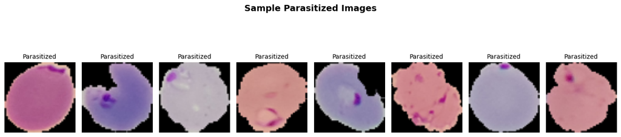

```python
# Display 8 sample parasitized images
parasitized_indices = np.where(train_labels == 1)[0][:8]

plt.figure(figsize=(14, 4))

for i, idx in enumerate(parasitized_indices):
    plt.subplot(1, 8, i + 1)
    plt.imshow(train_images[idx])
    plt.title("Parasitized", fontsize=10)
    plt.axis("off")

plt.suptitle("Sample Parasitized Images", fontsize=14, fontweight="bold")
plt.tight_layout()
plt.show()
```

### **Observations and Insights**

The parasitized blood smear images show distinct dark purple intracellular structures corresponding to *Plasmodium* parasites. Although the parasites vary in size, shape, number, and location, these visual characteristics provide discriminative features that convolutional neural networks (CNNs) can learn for automated malaria detection.

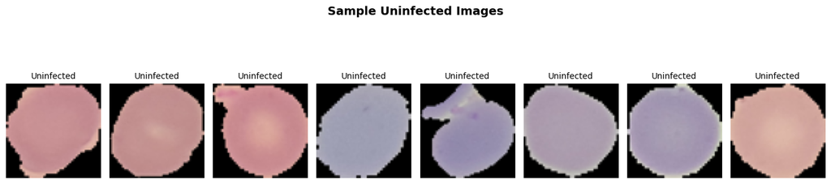

```python
# Display 8 sample uninfected images
uninfected_indices = np.where(train_labels == 0)[0][:8]

plt.figure(figsize=(14, 4))

for i, idx in enumerate(uninfected_indices):
    plt.subplot(1, 8, i + 1)
    plt.imshow(train_images[idx])
    plt.title("Uninfected", fontsize=10)
    plt.axis("off")

plt.suptitle("Sample Uninfected Images", fontsize=14, fontweight="bold")
plt.tight_layout()
plt.show()
```

### **Observations and Insights**

The uninfected blood smear images appear more uniform and lack the distinct intracellular parasite structures observed in parasitized cells. Nevertheless, variations in staining intensity, cell shape, orientation, and background indicate that the model must learn robust visual features rather than relying on a single distinguishing characteristic.

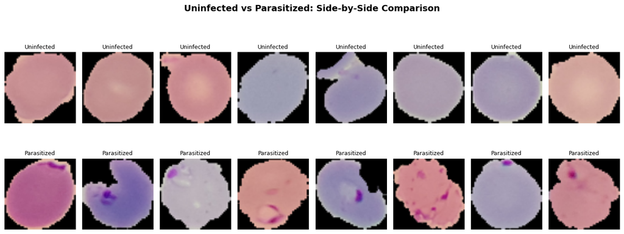

```python
># Display side-by-side comparison of uninfected and parasitized images
plt.figure(figsize=(14, 6))

for i in range(8):
    # Top row: uninfected
    plt.subplot(2, 8, i + 1)
    plt.imshow(train_images[uninfected_indices[i]])
    plt.title("Uninfected", fontsize=9)
    plt.axis("off")

    # Bottom row: parasitized
    plt.subplot(2, 8, i + 9)
    plt.imshow(train_images[parasitized_indices[i]])
    plt.title("Parasitized", fontsize=9)
    plt.axis("off")

plt.suptitle("Uninfected vs Parasitized: Side-by-Side Comparison", fontsize=14, fontweight="bold")
plt.tight_layout()
plt.show()
```

### **Observations and Insights**

The side-by-side comparison highlights the primary visual distinction between the two classes. Parasitized cells frequently contain one or more dark purple intracellular inclusions, whereas uninfected cells exhibit a relatively uniform appearance without these structures. At the same time, noticeable variation in staining intensity, cell morphology, orientation, and image quality exists within both classes. These observations demonstrate that malaria detection is not based on a single visual rule, reinforcing the need for convolutional neural networks to automatically learn complex and robust image features.

## **Image Dimensions and Pixel Characteristics**

### **Objective**

Before training a convolutional neural network, it is important to verify that all images have a consistent shape and understand how image information is represented numerically. Since CNNs operate on pixel values rather than visual patterns, confirming image dimensions and pixel intensity ranges helps ensure the dataset is correctly prepared for deep learning.

```python
# Display the shape of one sample image

print("Image Shape:", train_images[0].shape)
print("Data Type :", train_images[0].dtype)

# Display the minimum and maximum pixel values
print("\nMinimum Pixel Value:", train_images.min())
print("Maximum Pixel Value:", train_images.max())
```

```
Image Shape: (64, 64, 3)
Data Type : uint8

Minimum Pixel Value: 0
Maximum Pixel Value: 255
```

### **Observations and Insights**

The dataset consists of standardized **64 × 64 RGB images**, confirming that all samples share the same dimensions required for convolutional neural network (CNN) models. Images are stored as **unsigned 8-bit integers (`uint8`)**, with pixel intensities ranging from **0 to 255**, which is the standard format for digital color images.

Since CNNs learn directly from pixel values, the images will be **normalized** before model training to improve numerical stability and facilitate faster model convergence.

## **Pixel Characteristics**

### **Objective**

Pixel values represent the numerical information used by convolutional neural networks (CNNs) to learn image features. Examining the distribution of pixel intensities helps determine whether the images utilize the full range of color values and provides justification for normalizing the data before model training.

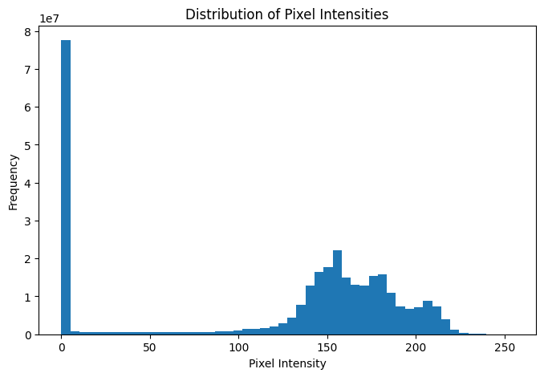

```python
# Display the distribution of pixel intensities

plt.figure(figsize=(8, 5))

plt.hist(train_images.ravel(), bins=50)

plt.title("Distribution of Pixel Intensities")
plt.xlabel("Pixel Intensity")
plt.ylabel("Frequency")

plt.show()
```

### **Observations and Insights**

The pixel intensity distribution spans the full range of **0 to 255**, confirming that the images retain the complete spectrum of RGB intensity values. A prominent peak at **0** is observed, which corresponds to the black background surrounding many of the blood smear images. The remaining pixel values are concentrated primarily between **approximately 120 and 220**, reflecting the staining characteristics of red blood cells and intracellular parasite structures.

The wide distribution of pixel intensities indicates that the images contain sufficient contrast and visual information for feature extraction. However, because the pixel values are on different numerical scales, they will be **normalized before model training** to improve training stability and facilitate faster convergence of the convolutional neural network.

## **Class Distribution**

### **Objective**

Before developing deep learning models, it is important to verify whether the dataset is balanced across the two target classes. A balanced dataset reduces the likelihood of model bias toward one class and enables a more reliable evaluation of classification performance.

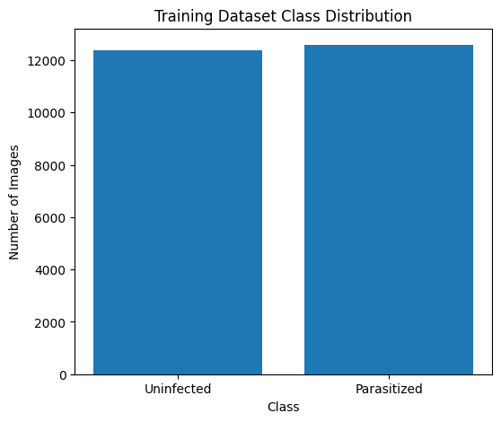

```python
# Create a dataframe for plotting the class distribution
class_counts = pd.DataFrame({
    "Class": ["Uninfected", "Parasitized"],
    "Count": [
        np.sum(train_labels == 0),
        np.sum(train_labels == 1)
    ]
})

plt.figure(figsize=(6,5))

plt.bar(class_counts["Class"], class_counts["Count"])

plt.title("Training Dataset Class Distribution")
plt.xlabel("Class")
plt.ylabel("Number of Images")

plt.show()
```

### **Observations and Insights**

The class distribution confirms that the training dataset is well balanced, containing **12,376 uninfected** and **12,582 parasitized** blood smear images. The difference between the two classes is only **206 images (approximately 0.8%)**, indicating minimal class imbalance.

A balanced dataset is advantageous for supervised learning because it reduces the likelihood that the convolutional neural network (CNN) will favor one class over the other during training. Consequently, additional class-balancing techniques, such as oversampling or undersampling, are not necessary for this dataset.

## **Mean Image Comparison**

### **Objective**

Individual blood smear images exhibit natural variation in cell shape, staining intensity, and parasite appearance. To better understand the overall visual characteristics of each class, the average (mean) image is computed separately for parasitized and uninfected cells. Averaging thousands of images helps emphasize common patterns while reducing random variation and image-specific noise.

```python
# Function to compute and display the mean image

def display_mean_image(images, title):

    # Calculate the average image
    mean_image = np.mean(images, axis=0)

    # Display the average image
    plt.figure(figsize=(5,5))
    plt.imshow(mean_image.astype(np.uint8))
    plt.title(title)
    plt.axis("off")
    plt.show()

    return mean_image
```

```python
# Separate images by class

parasitized_images = train_images[train_labels == 1]

uninfected_images = train_images[train_labels == 0]
```

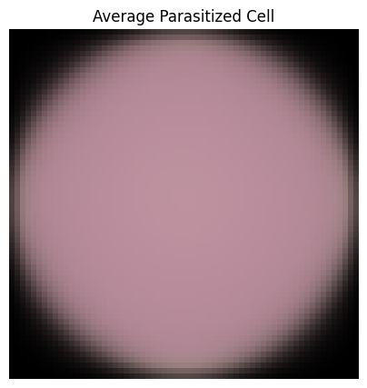

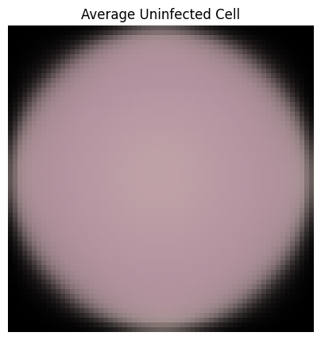

```python
# Display the average image for each class

parasitized_mean = display_mean_image(
    parasitized_images,
    "Average Parasitized Cell"
)

uninfected_mean = display_mean_image(
    uninfected_images,
    "Average Uninfected Cell"
)
```

### **Observations and Insights**

The mean images for the parasitized and uninfected classes appear highly similar, with both displaying the overall circular morphology and pink staining characteristic of red blood cells. This result is expected because averaging thousands of images smooths individual differences and emphasizes only the common visual structures shared across each class.

Notably, distinct malaria parasites are not visible in the mean parasitized image because parasite locations vary from one cell to another and are effectively averaged out. This observation highlights the complexity of the classification task and demonstrates why convolutional neural networks are needed. Rather than relying on average appearance, CNNs learn localized features and spatial patterns that distinguish parasitized from uninfected cells.

## **HSV Color Space Exploration**

### **Objective**

Images are commonly stored in the RGB (Red, Green, Blue) color space. However, alternative color representations can highlight different visual characteristics. The HSV (Hue, Saturation, Value) color space separates color information from brightness, making it useful for understanding image composition and illustrating common image-processing techniques used in computer vision.

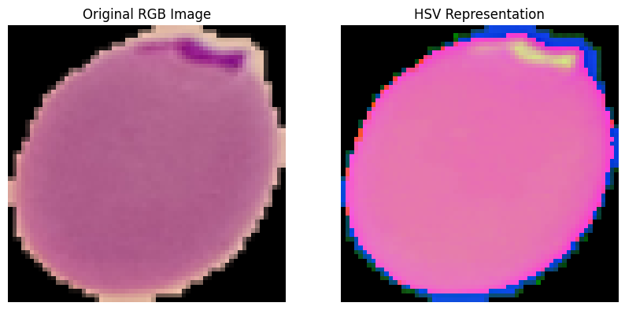

```python
from matplotlib.colors import rgb_to_hsv

# Select one sample image
sample_image = train_images[0]

# Convert RGB image to HSV
hsv_image = rgb_to_hsv(sample_image.astype("float32") / 255)

# Display RGB and HSV images
plt.figure(figsize=(10,5))

plt.subplot(1,2,1)
plt.imshow(sample_image)
plt.title("Original RGB Image")
plt.axis("off")

plt.subplot(1,2,2)
plt.imshow(hsv_image)
plt.title("HSV Representation")
plt.axis("off")

plt.show()
```

### **Observations and Insights**

The HSV representation displays the same blood smear image using an alternative color space that separates **Hue (color), Saturation (color intensity), and Value (brightness)**. Compared with the original RGB image, the HSV image emphasizes differences in color and brightness, making certain intracellular structures and staining variations more visually distinct.

Although HSV is commonly used in image segmentation and traditional computer vision applications, the deep learning models developed in this project will be trained using the original RGB images. This comparison is included to illustrate an alternative image representation and to demonstrate how different color spaces may highlight specific visual characteristics of microscopic images.

## **Gaussian Blur**

### **Objective**

Microscopic images often contain small variations caused by staining, illumination, and image acquisition. Gaussian blurring is a classical image-processing technique that smooths an image by reducing high-frequency noise while preserving the overall structure of the object. This visualization demonstrates how image smoothing affects the appearance of blood smear images and introduces another commonly used preprocessing technique in computer vision.

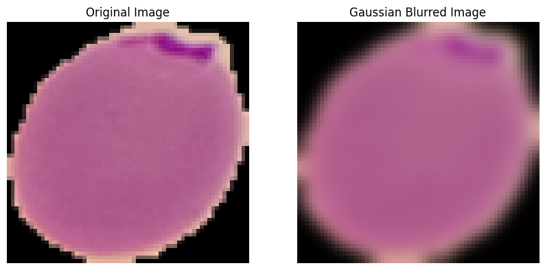

```python
from PIL import ImageFilter

# Select one sample image
sample_image = train_images[0]

# Convert NumPy array to PIL image
pil_image = Image.fromarray(sample_image.astype(np.uint8))

# Apply Gaussian Blur
blurred_image = pil_image.filter(ImageFilter.GaussianBlur(radius=2))

# Display original and blurred images
plt.figure(figsize=(10,5))

plt.subplot(1,2,1)
plt.imshow(sample_image)
plt.title("Original Image")
plt.axis("off")

plt.subplot(1,2,2)
plt.imshow(blurred_image)
plt.title("Gaussian Blurred Image")
plt.axis("off")

plt.show()
```

### **Observations and Insights**

The Gaussian-blurred image appears smoother than the original image, with fine details and sharp edges becoming less pronounced while preserving the overall morphology of the red blood cell. This demonstrates how Gaussian filtering reduces high-frequency noise by averaging neighboring pixel values.

Although Gaussian blurring can improve image quality by reducing noise, excessive smoothing may also remove subtle parasite-specific features that are important for accurate classification. Consequently, the convolutional neural networks developed in this project will be trained using the original normalized images rather than blurred images.

## **EDA Summary**

The exploratory data analysis confirmed that the malaria image dataset is complete, well structured, and suitable for deep learning. The dataset includes standardized **64 × 64 RGB images**, with a nearly balanced training set and a perfectly balanced testing set. Visual inspection showed meaningful differences between parasitized and uninfected cells, while pixel-level analysis confirmed the need for normalization before CNN model development.

Overall, the EDA supports moving forward to image preprocessing and model building.

```python
print(train_images.dtype)
print(train_images.min())
print(train_images.max())
```

```
uint8
0
255
```

# **5. Image Preprocessing**

## **Objective**

Before training a convolutional neural network (CNN), the image data must be preprocessed to improve learning efficiency and model performance. Since the original images contain pixel values ranging from **0 to 255**, the first preprocessing step is **normalization**, which rescales all pixel values to the range **0–1**.

Normalization improves numerical stability, accelerates model convergence, and represents a standard preprocessing technique for deep learning models. This section also prepares the image labels for classification and verifies that the dataset is correctly formatted before CNN model development.

This section includes:

- Image normalization
- Verification of normalized images
- One-hot encoding of class labels
- Final dataset verification before model development

```python
# Normalize image pixel values to the range 0–1

train_images = train_images.astype(np.float32) / 255.0
test_images = test_images.astype(np.float32) / 255.0
```

```python
print(train_images.dtype)
print(train_images.min())
print(train_images.max())

print(test_images.dtype)
print(test_images.min())
print(test_images.max())
```

```
float32
0.0
1.0
float32
0.0
1.0
```

### **Observations and Insights**

The image arrays were successfully normalized from the original pixel range of **0–255** to a standardized range of **0–1**. Both training and testing images are now stored as **float32** arrays, which is the preferred numerical format for deep learning models.

This normalization step improves numerical stability and helps the convolutional neural network learn more efficiently during model training.

## **Label Encoding**

### **Objective**

The target labels currently use binary numeric values, where **0 = uninfected** and **1 = parasitized**. Since the CNN models will use a final dense layer with **2 output neurons** and a **softmax activation function**, the labels must be converted into a one-hot encoded format.

In one-hot encoding, each class is represented as a two-element vector:

- **Uninfected:** `[1, 0]`
- **Parasitized:** `[0, 1]`

```python
# Import function for one-hot encoding
from tensorflow.keras.utils import to_categorical

# Convert labels to one-hot encoded format
train_labels = to_categorical(train_labels, num_classes=2)
test_labels = to_categorical(test_labels, num_classes=2)
```

```python
# Verify label encoding
print("Training Labels Shape:", train_labels.shape)
print("Testing Labels Shape :", test_labels.shape)

print("\nExample Encoded Labels:")
print(train_labels[:5])
```

```
Training Labels Shape: (24958, 2)
Testing Labels Shape : (2600, 2)

Example Encoded Labels:
[[0. 1.]
 [0. 1.]
 [0. 1.]
 [0. 1.]
 [0. 1.]]
```

```python
# Shuffle the training data before model training

np.random.seed(42)

shuffle_index = np.random.permutation(len(train_images))

train_images = train_images[shuffle_index]
train_labels = train_labels[shuffle_index]

print("Training data shuffled successfully.")
```

```
Training data shuffled successfully.
```

```python
# Verify that labels are now mixed

print("First 10 encoded labels after shuffling:\n")
print(train_labels[:10])
```

```
First 10 encoded labels after shuffling:

[[1. 0.]
 [0. 1.]
 [0. 1.]
 [0. 1.]
 [1. 0.]
 [0. 1.]
 [0. 1.]
 [0. 1.]
 [1. 0.]
 [0. 1.]]
```

### **Observations and Insights**

The class labels were successfully converted from binary numeric values to one-hot encoded vectors. The training labels now have a shape of **(24,958, 2)** and the testing labels have a shape of **(2,600, 2)**, confirming that each image is represented by two output values corresponding to the two malaria classes.

One-hot encoding is the standard label format for multi-class classification using a softmax output layer and categorical cross-entropy loss. The dataset is now fully prepared for convolutional neural network (CNN) model development.

# **6. Baseline Convolutional Neural Network (CNN)**

## **Objective**

The goal of this section is to build an initial convolutional neural network (CNN) model for classifying malaria blood smear images as **parasitized** or **uninfected**. This baseline model provides the first deep learning benchmark against which later improved models can be compared.

CNNs are well suited for image classification because they can automatically learn spatial patterns such as edges, shapes, textures, and localized parasite-like structures directly from image pixels.

This section includes:

- Importing deep learning libraries
- Defining the baseline CNN architecture
- Compiling the model
- Training the model
- Evaluating model performance
- Reviewing training and validation accuracy

```python
# Import libraries required for CNN model development

import tensorflow as tf

from tensorflow.keras import backend
from tensorflow.keras.models import Sequential
from tensorflow.keras.layers import Conv2D, MaxPooling2D, Dense, Flatten, Dropout
from tensorflow.keras.callbacks import EarlyStopping, ModelCheckpoint

# Clear previous Keras/TensorFlow session
backend.clear_session()

# Set random seeds for reproducibility
np.random.seed(42)
tf.random.set_seed(42)
```

## **Baseline CNN Architecture**

### **Objective**

The first model developed in this project is a baseline convolutional neural network (CNN). The purpose of this model is to establish an initial benchmark for malaria image classification before exploring more advanced architectures and optimization techniques.

The model consists of two convolutional blocks for feature extraction, followed by fully connected layers for classification. Rectified Linear Unit (ReLU) activation is used in the hidden layers to introduce non-linearity, while a softmax activation function is used in the output layer to estimate the probability of each class.

The baseline architecture includes:

- Two convolutional layers
- Two max-pooling layers
- One flatten layer
- One fully connected hidden layer
- One output layer with softmax activation

```python
# Build the baseline CNN model

baseline_model = Sequential([

    # First Convolution Block
    Conv2D(
        filters=32,
        kernel_size=(3, 3),
        activation="relu",
        input_shape=(64, 64, 3)
    ),
    MaxPooling2D(pool_size=(2, 2)),

    # Second Convolution Block
    Conv2D(
        filters=64,
        kernel_size=(3, 3),
        activation="relu"
    ),
    MaxPooling2D(pool_size=(2, 2)),

    # Flatten feature maps
    Flatten(),

    # Fully connected layer
    Dense(
        128,
        activation="relu"
    ),

    # Output layer
    Dense(
        2,
        activation="softmax"
    )
])
```

```python
# Display the baseline model architecture
baseline_model.summary()
```

```
Model: "sequential"
```

```
┏━━━━━━━━━━━━━━━━━━━━━━━━━━━━━━━━━┳━━━━━━━━━━━━━━━━━━━━━━━━┳━━━━━━━━━━━━━━━┓
┃ Layer (type)                    ┃ Output Shape           ┃       Param # ┃
┡━━━━━━━━━━━━━━━━━━━━━━━━━━━━━━━━━╇━━━━━━━━━━━━━━━━━━━━━━━━╇━━━━━━━━━━━━━━━┩
│ conv2d (Conv2D)                 │ (None, 62, 62, 32)     │           896 │
├─────────────────────────────────┼────────────────────────┼───────────────┤
│ max_pooling2d (MaxPooling2D)    │ (None, 31, 31, 32)     │             0 │
├─────────────────────────────────┼────────────────────────┼───────────────┤
│ conv2d_1 (Conv2D)               │ (None, 29, 29, 64)     │        18,496 │
├─────────────────────────────────┼────────────────────────┼───────────────┤
│ max_pooling2d_1 (MaxPooling2D)  │ (None, 14, 14, 64)     │             0 │
├─────────────────────────────────┼────────────────────────┼───────────────┤
│ flatten (Flatten)               │ (None, 12544)          │             0 │
├─────────────────────────────────┼────────────────────────┼───────────────┤
│ dense (Dense)                   │ (None, 128)            │     1,605,760 │
├─────────────────────────────────┼────────────────────────┼───────────────┤
│ dense_1 (Dense)                 │ (None, 2)              │           258 │
└─────────────────────────────────┴────────────────────────┴───────────────┘
```

```
 Total params: 1,625,410 (6.20 MB)
```

```
 Trainable params: 1,625,410 (6.20 MB)
```

```
 Non-trainable params: 0 (0.00 B)
```

### **Understanding the Baseline CNN Architecture**

The model summary provides an overview of the neural network architecture, including the sequence of layers, the output dimensions after each operation, and the number of trainable parameters. Together, these layers enable the CNN to progressively learn increasingly complex image features before making the final classification.

| Layer | Purpose | Why it is Used |
| --- | --- | --- |
| **Conv2D (32 filters)** | Detects basic image features | Learns simple patterns such as edges, color transitions, and small parasite-like structures. |
| **MaxPooling2D** | Reduces image size | Decreases computational cost while preserving the most important features. |
| **Conv2D (64 filters)** | Learns more complex features | Builds upon the first layer to recognize larger and more informative image patterns. |
| **MaxPooling2D** | Further feature reduction | Compresses feature maps while retaining the strongest signals. |
| **Flatten** | Converts feature maps into a vector | Prepares the extracted image features for classification by the dense layers. |
| **Dense (128 neurons)** | Learns feature combinations | Integrates all extracted features to distinguish infected from uninfected cells. |
| **Dense (2 neurons, Softmax)** | Final classification | Produces the probability that an image belongs to either the parasitized or uninfected class. |

## **Model Compilation**

### **Objective**

Before the CNN can begin learning, the model must be compiled. Model compilation specifies three essential components that govern the learning process:

- **Loss Function:** Measures how far the model's predictions are from the true labels.
- **Optimizer:** Updates the model's weights to reduce prediction errors during training.
- **Evaluation Metric:** Measures model performance throughout training.

For this binary image classification problem, the model uses the **Adam optimizer**, **categorical cross-entropy loss**, and **accuracy** as the evaluation metric.

```python
# Compile the baseline CNN model

baseline_model.compile(
    optimizer="adam",
    loss="categorical_crossentropy",
    metrics=["accuracy"]
)
```

```python
print("Baseline CNN model compiled successfully.")
```

```
Baseline CNN model compiled successfully.
```

## **Training the Baseline CNN**

### **Objective**

Once the CNN architecture has been defined and compiled, the model is trained using the labeled training images. During training, the CNN repeatedly examines the training images, compares its predictions with the true labels, calculates prediction errors, and updates its internal parameters to improve future predictions.

The learning process is repeated over multiple **epochs**, where one epoch represents one complete pass through the entire training dataset. A portion of the training data is reserved as a **validation set** to monitor model performance on previously unseen data and detect potential overfitting.

This section trains the baseline CNN and records the training history for later evaluation and visualization.

```python
history = baseline_model.fit(
    train_images,
    train_labels,
    validation_split=0.20,
    epochs=10,
    batch_size=32,
    verbose=1
)
```

```
624/624 ━━━━━━━━━━━━━━━━━━━━ 128s 203ms/step - accuracy: 0.8218 - loss: 0.3868 - val_accuracy: 0.9329 - val_loss: 0.1749
624/624 ━━━━━━━━━━━━━━━━━━━━ 122s 195ms/step - accuracy: 0.9509 - loss: 0.1421 - val_accuracy: 0.9657 - val_loss: 0.1058
624/624 ━━━━━━━━━━━━━━━━━━━━ 118s 190ms/step - accuracy: 0.9659 - loss: 0.1044 - val_accuracy: 0.9754 - val_loss: 0.0832
624/624 ━━━━━━━━━━━━━━━━━━━━ 145s 195ms/step - accuracy: 0.9730 - loss: 0.0818 - val_accuracy: 0.9760 - val_loss: 0.0803
624/624 ━━━━━━━━━━━━━━━━━━━━ 123s 198ms/step - accuracy: 0.9792 - loss: 0.0619 - val_accuracy: 0.9778 - val_loss: 0.0712
624/624 ━━━━━━━━━━━━━━━━━━━━ 119s 191ms/step - accuracy: 0.9844 - loss: 0.0502 - val_accuracy: 0.9786 - val_loss: 0.0804
624/624 ━━━━━━━━━━━━━━━━━━━━ 144s 194ms/step - accuracy: 0.9866 - loss: 0.0401 - val_accuracy: 0.9726 - val_loss: 0.0981
624/624 ━━━━━━━━━━━━━━━━━━━━ 122s 196ms/step - accuracy: 0.9895 - loss: 0.0314 - val_accuracy: 0.9742 - val_loss: 0.1038
624/624 ━━━━━━━━━━━━━━━━━━━━ 118s 189ms/step - accuracy: 0.9918 - loss: 0.0250 - val_accuracy: 0.9764 - val_loss: 0.0940
624/624 ━━━━━━━━━━━━━━━━━━━━ 144s 193ms/step - accuracy: 0.9924 - loss: 0.0224 - val_accuracy: 0.9734 - val_loss: 0.1396
```

## **7. Baseline Model Evaluation**

### **Objective**

After training, the baseline convolutional neural network (CNN) is evaluated using the independent testing dataset. These images were not used during model training or validation and therefore provide an unbiased assessment of the model's ability to generalize to previously unseen blood smear images.

Model evaluation begins by measuring the overall **test loss** and **classification accuracy**. The trained CNN then generates predictions for every test image, which are compared with the true class labels to provide a comprehensive assessment of model performance.

This evaluation includes:

- Overall test performance (loss and accuracy)
- Generation of model predictions
- Confusion matrix
- Classification report (precision, recall, and F1-score)
- Receiver Operating Characteristic (ROC) curve and Area Under the Curve (AUC)
- Visualization of correctly and incorrectly classified images
- Overall model evaluation summary

```python
# Evaluate the baseline CNN on the independent test dataset

test_loss, test_accuracy = baseline_model.evaluate(
    test_images,
    test_labels,
    verbose=1
)

print("\nTest Loss     :", round(test_loss, 4))
print("Test Accuracy :", round(test_accuracy * 100, 2), "%")
```

```
82/82 ━━━━━━━━━━━━━━━━━━━━ 5s 55ms/step - accuracy: 0.9700 - loss: 0.1377

Test Loss     : 0.1377
Test Accuracy : 97.0 %
```

### **Observations and Insights**

Because overall accuracy alone does not reveal the types of prediction errors made by the model, the next step is to generate class predictions and examine the confusion matrix, classification report, ROC curve, and representative correctly and incorrectly classified images.

### **Generate Model Predictions**

#### **Objective**

After evaluating the overall performance of the baseline CNN, the next step is to generate predictions for each image in the independent testing dataset. The trained CNN produces a probability for each class (parasitized and uninfected). These probabilities are then converted into predicted class labels by selecting the class with the highest probability.

The predicted labels are required for the remaining evaluation analyses, including the confusion matrix, classification report, receiver operating characteristic (ROC) curve, and visualization of correctly and incorrectly classified images.

```python
# Generate predicted probabilities for the test dataset
baseline_predictions = baseline_model.predict(test_images)

# Convert predicted probabilities into class labels
baseline_pred_classes = np.argmax(baseline_predictions, axis=1)

# Convert one-hot encoded true labels back into class labels
baseline_true_classes = np.argmax(test_labels, axis=1)
```

```
82/82 ━━━━━━━━━━━━━━━━━━━━ 4s 43ms/step
```

```python
print("Predicted classes shape:", baseline_pred_classes.shape)
print("True classes shape     :", baseline_true_classes.shape)

print("\nFirst 10 predicted labels:", baseline_pred_classes[:10])
print("First 10 true labels     :", baseline_true_classes[:10])
```

```
Predicted classes shape: (2600,)
True classes shape     : (2600,)

First 10 predicted labels: [1 1 0 1 1 1 1 1 1 1]
First 10 true labels     : [1 1 1 1 1 1 1 1 1 1]
```

### **Observations and Insights**

The trained CNN successfully generated predictions for all **2,600** images in the independent testing dataset. The predicted class labels and true class labels have identical dimensions, confirming that every test image has a corresponding prediction available for evaluation.

## **Confusion Matrix**

### **Objective**

Overall accuracy summarizes the proportion of correctly classified images but does not indicate the types of prediction errors made by the model. A confusion matrix provides a more detailed evaluation by comparing the predicted class labels with the true class labels for every image in the independent testing dataset.

The confusion matrix identifies the number of correctly classified parasitized and uninfected cells, as well as the number of false positive and false negative predictions. These results provide insight into the strengths and weaknesses of the CNN and form the basis for calculating precision, recall, and F1-score.

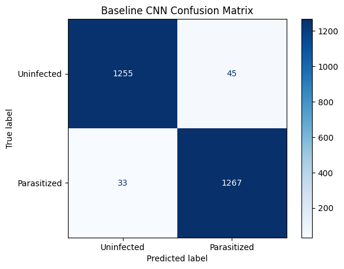

```python
from sklearn.metrics import confusion_matrix, ConfusionMatrixDisplay
import matplotlib.pyplot as plt

# Compute the confusion matrix
cm = confusion_matrix(
    baseline_true_classes,
    baseline_pred_classes
)

# Display the confusion matrix
disp = ConfusionMatrixDisplay(
    confusion_matrix=cm,
    display_labels=["Uninfected", "Parasitized"]
)

plt.figure(figsize=(6,6))
disp.plot(cmap="Blues", values_format="d")
plt.title("Baseline CNN Confusion Matrix")
plt.grid(False)
plt.show()
```

```python
print("Prediction shape:", baseline_predictions.shape)
print("\nFirst 5 prediction probabilities:\n")
print(baseline_predictions[:5])
```

```
Prediction shape: (2600, 2)

First 5 prediction probabilities:

[[4.7672010e-16 9.9999994e-01]
 [1.2218058e-09 9.9999994e-01]
 [9.9835408e-01 1.6459282e-03]
 [1.7870234e-37 9.9999994e-01]
 [4.3945338e-12 9.9999994e-01]]
```

```python
print("Unique predicted classes:")
print(np.unique(baseline_pred_classes, return_counts=True))
```

```
Unique predicted classes:
(array([0, 1]), array([1288, 1312]))
```

```python
print("Unique true classes:")
print(np.unique(baseline_true_classes, return_counts=True))
```

```
Unique true classes:
(array([0, 1]), array([1300, 1300]))
```

## **Classification Report**

### **Objective**

While the confusion matrix summarizes the number of correct and incorrect predictions, the classification report provides additional performance metrics for each class individually. Specifically, it reports **precision**, **recall**, **F1-score**, and **support**, offering a more comprehensive assessment of the CNN's classification performance.

These metrics are particularly important in medical image classification because they quantify not only the model's overall accuracy but also its ability to correctly identify malaria-infected and uninfected blood smear images while minimizing false positive and false negative predictions.

```python
from sklearn.metrics import classification_report

# Generate classification report
report = classification_report(
    baseline_true_classes,
    baseline_pred_classes,
    target_names=["Uninfected", "Parasitized"]
)

print(report)
```

```
              precision    recall  f1-score   support

  Uninfected       0.97      0.97      0.97      1300
 Parasitized       0.97      0.97      0.97      1300

    accuracy                           0.97      2600
   macro avg       0.97      0.97      0.97      2600
weighted avg       0.97      0.97      0.97      2600
```

## **Receiver Operating Characteristic (ROC) Curve and Area Under the Curve (AUC)**

### **Objective**

While the confusion matrix and classification report evaluate model performance using a single decision threshold, the Receiver Operating Characteristic (ROC) curve assesses the model's performance across all possible classification thresholds. The ROC curve illustrates the trade-off between the True Positive Rate (Sensitivity) and the False Positive Rate, providing a comprehensive view of the model's discriminative ability.

The Area Under the ROC Curve (AUC) summarizes the ROC curve into a single value ranging from 0.5 to 1.0. An AUC closer to 1.0 indicates excellent discrimination between parasitized and uninfected blood smear images.

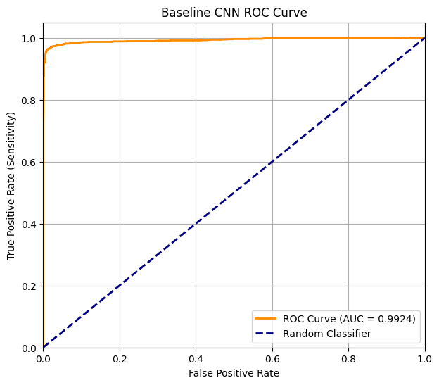

```
AUC = 0.9924
```

```python
from sklearn.metrics import roc_curve, auc
import matplotlib.pyplot as plt

# Probability of the positive (Parasitized) class
y_score = baseline_predictions[:, 1]

# Compute ROC curve
fpr, tpr, thresholds = roc_curve(
    baseline_true_classes,
    y_score
)

# Compute Area Under the Curve
roc_auc = auc(fpr, tpr)

# Plot ROC Curve
plt.figure(figsize=(7,6))
plt.plot(fpr, tpr,
         color="darkorange",
         lw=2,
         label=f"ROC Curve (AUC = {roc_auc:.4f})")
plt.plot([0,1],[0,1],
         color="navy",
         lw=2,
         linestyle="--",
         label="Random Classifier")

plt.xlim([0.0,1.0])
plt.ylim([0.0,1.05])

plt.xlabel("False Positive Rate")
plt.ylabel("True Positive Rate (Sensitivity)")
plt.title("Baseline CNN ROC Curve")

plt.legend(loc="lower right")
plt.grid(True)

plt.show()

print(f"AUC = {roc_auc:.4f}")
```

### **Observations and Insights**

The ROC curve demonstrates the baseline CNN's excellent ability to distinguish between parasitized and uninfected blood smear images across all possible classification thresholds. The curve remains close to the upper-left corner of the graph, indicating a high true positive rate while maintaining a very low false positive rate.

These findings are consistent with the high classification accuracy, confusion matrix, and classification report, further confirming the robustness and reliability of the baseline CNN.

# **8. Visualization of Model Predictions**

## **Objective**

While quantitative performance metrics summarize the overall performance of the CNN, visualizing individual predictions provides a more intuitive understanding of how the model performs on real blood smear images. Examining correctly and incorrectly classified images helps identify the types of patterns the model recognizes successfully as well as the characteristics of images that remain challenging.

This section presents examples of both correctly classified and misclassified blood smear images from the independent testing dataset to provide a qualitative assessment of the baseline CNN.

## **Correctly Classified Images**

### **Objective**

Correctly classified images illustrate examples where the CNN successfully identified the appropriate class. Visual inspection of these images helps demonstrate that the model has learned meaningful visual features associated with parasitized and uninfected red blood cells.

These examples provide confidence that the CNN is recognizing biologically relevant image characteristics rather than making random predictions.

```python
# Identify correctly classified images

correct_indices = np.where(
    baseline_pred_classes == baseline_true_classes
)[0]

print("Correctly classified images:", len(correct_indices))
```

```
Correctly classified images: 2522
```

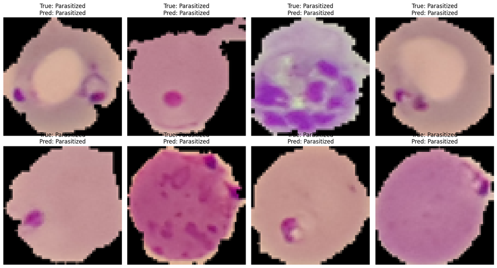

```python
# Display correctly classified images

plt.figure(figsize=(15,8))

for i in range(8):

    idx = correct_indices[i]

    plt.subplot(2,4,i+1)

    plt.imshow(test_images[idx])

    plt.title(
        f"True: {'Parasitized' if baseline_true_classes[idx]==1 else 'Uninfected'}\n"
        f"Pred: {'Parasitized' if baseline_pred_classes[idx]==1 else 'Uninfected'}"
    )

    plt.axis("off")

plt.tight_layout()

plt.show()
```

### **Observations and Insights**

The examples above illustrate blood smear images that were correctly classified by the baseline CNN. In each case, the predicted class matches the true label, demonstrating that the model successfully learned visual characteristics associated with malaria parasites and healthy red blood cells.

## **Incorrectly Classified Images**

### **Objective**

Although the baseline CNN achieved excellent overall performance, a small number of images were misclassified. Examining these difficult cases helps identify situations where image characteristics may overlap between classes or where staining quality, lighting, or cell morphology may introduce ambiguity.

Understanding these errors provides valuable insight into potential limitations of the model and identifies opportunities for future improvement.

```python
# Identify incorrectly classified images

incorrect_indices = np.where(
    baseline_pred_classes != baseline_true_classes
)[0]

print("Incorrectly classified images:", len(incorrect_indices))
```

```
Incorrectly classified images: 78
```

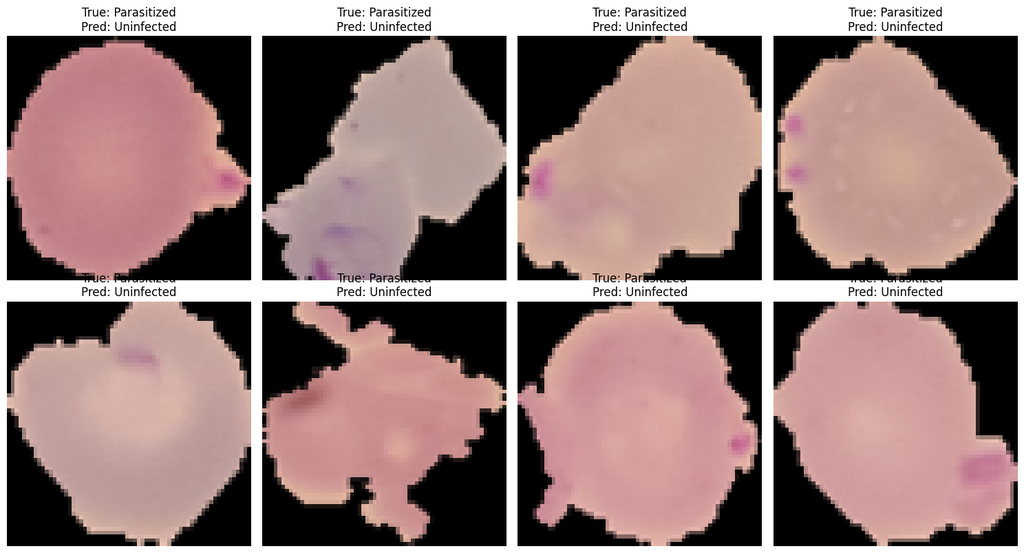

```python
# Display incorrectly classified images

plt.figure(figsize=(15,8))

n_images = min(8, len(incorrect_indices))

for i in range(n_images):

    idx = incorrect_indices[i]

    plt.subplot(2,4,i+1)

    plt.imshow(test_images[idx])

    plt.title(
        f"True: {'Parasitized' if baseline_true_classes[idx]==1 else 'Uninfected'}\n"
        f"Pred: {'Parasitized' if baseline_pred_classes[idx]==1 else 'Uninfected'}"
    )

    plt.axis("off")

plt.tight_layout()

plt.show()
```

### **Observations and Insights**

The misclassified images represent challenging cases where the CNN produced incorrect predictions. Visual inspection suggests that several of these images contain subtle parasite features, low contrast, irregular staining, or ambiguous cellular morphology, making discrimination more difficult.

# **9. Overall Model Evaluation Summary**

# **10. Improved CNN Model**

## **Objective**

The baseline CNN demonstrated strong performance; however, additional convolutional layers and dropout may help the model learn more complex image features while reducing overfitting. This section develops an improved CNN architecture and compares its performance with the baseline model.

```python
# Clear previous model session
backend.clear_session()

# Set seeds for reproducibility
np.random.seed(42)
tf.random.set_seed(42)

# Build Improved CNN Model
model1 = Sequential([
    Conv2D(32, (3, 3), activation="relu", padding="same", input_shape=(64, 64, 3)),
    MaxPooling2D((2, 2)),

    Conv2D(64, (3, 3), activation="relu", padding="same"),
    MaxPooling2D((2, 2)),

    Conv2D(128, (3, 3), activation="relu", padding="same"),
    MaxPooling2D((2, 2)),

    Flatten(),

    Dense(128, activation="relu"),
    Dropout(0.5),

    Dense(2, activation="softmax")
])

model1.summary()
```

```
Model: "sequential"
```

```
┏━━━━━━━━━━━━━━━━━━━━━━━━━━━━━━━━━┳━━━━━━━━━━━━━━━━━━━━━━━━┳━━━━━━━━━━━━━━━┓
┃ Layer (type)                    ┃ Output Shape           ┃       Param # ┃
┡━━━━━━━━━━━━━━━━━━━━━━━━━━━━━━━━━╇━━━━━━━━━━━━━━━━━━━━━━━━╇━━━━━━━━━━━━━━━┩
│ conv2d (Conv2D)                 │ (None, 64, 64, 32)     │           896 │
├─────────────────────────────────┼────────────────────────┼───────────────┤
│ max_pooling2d (MaxPooling2D)    │ (None, 32, 32, 32)     │             0 │
├─────────────────────────────────┼────────────────────────┼───────────────┤
│ conv2d_1 (Conv2D)               │ (None, 32, 32, 64)     │        18,496 │
├─────────────────────────────────┼────────────────────────┼───────────────┤
│ max_pooling2d_1 (MaxPooling2D)  │ (None, 16, 16, 64)     │             0 │
├─────────────────────────────────┼────────────────────────┼───────────────┤
│ conv2d_2 (Conv2D)               │ (None, 16, 16, 128)    │        73,856 │
├─────────────────────────────────┼────────────────────────┼───────────────┤
│ max_pooling2d_2 (MaxPooling2D)  │ (None, 8, 8, 128)      │             0 │
├─────────────────────────────────┼────────────────────────┼───────────────┤
│ flatten (Flatten)               │ (None, 8192)           │             0 │
├─────────────────────────────────┼────────────────────────┼───────────────┤
│ dense (Dense)                   │ (None, 128)            │     1,048,704 │
├─────────────────────────────────┼────────────────────────┼───────────────┤
│ dropout (Dropout)               │ (None, 128)            │             0 │
├─────────────────────────────────┼────────────────────────┼───────────────┤
│ dense_1 (Dense)                 │ (None, 2)              │           258 │
└─────────────────────────────────┴────────────────────────┴───────────────┘
```

```
 Total params: 1,142,210 (4.36 MB)
```

```
 Trainable params: 1,142,210 (4.36 MB)
```

```
 Non-trainable params: 0 (0.00 B)
```

```python
# Compile Improved CNN Model
model1.compile(
    optimizer="adam",
    loss="categorical_crossentropy",
    metrics=["accuracy"]
)
```

```python
# Train Improved CNN Model
history1 = model1.fit(
    train_images,
    train_labels,
    validation_split=0.20,
    epochs=10,
    batch_size=32,
    verbose=1
)
```

```
624/624 ━━━━━━━━━━━━━━━━━━━━ 199s 314ms/step - accuracy: 0.8729 - loss: 0.2733 - val_accuracy: 0.9798 - val_loss: 0.0593
624/624 ━━━━━━━━━━━━━━━━━━━━ 197s 316ms/step - accuracy: 0.9731 - loss: 0.0867 - val_accuracy: 0.9816 - val_loss: 0.0549
624/624 ━━━━━━━━━━━━━━━━━━━━ 212s 332ms/step - accuracy: 0.9767 - loss: 0.0719 - val_accuracy: 0.9840 - val_loss: 0.0485
624/624 ━━━━━━━━━━━━━━━━━━━━ 197s 316ms/step - accuracy: 0.9781 - loss: 0.0631 - val_accuracy: 0.9854 - val_loss: 0.0456
624/624 ━━━━━━━━━━━━━━━━━━━━ 201s 315ms/step - accuracy: 0.9792 - loss: 0.0593 - val_accuracy: 0.9824 - val_loss: 0.0525
624/624 ━━━━━━━━━━━━━━━━━━━━ 209s 326ms/step - accuracy: 0.9798 - loss: 0.0547 - val_accuracy: 0.9844 - val_loss: 0.0455
624/624 ━━━━━━━━━━━━━━━━━━━━ 204s 327ms/step - accuracy: 0.9810 - loss: 0.0495 - val_accuracy: 0.9842 - val_loss: 0.0483
624/624 ━━━━━━━━━━━━━━━━━━━━ 197s 316ms/step - accuracy: 0.9823 - loss: 0.0467 - val_accuracy: 0.9778 - val_loss: 0.0681
624/624 ━━━━━━━━━━━━━━━━━━━━ 209s 327ms/step - accuracy: 0.9835 - loss: 0.0450 - val_accuracy: 0.9850 - val_loss: 0.0484
624/624 ━━━━━━━━━━━━━━━━━━━━ 197s 316ms/step - accuracy: 0.9858 - loss: 0.0389 - val_accuracy: 0.9798 - val_loss: 0.0682
```

## **Improved CNN Evaluation**

### **Objective**

Following training, the improved convolutional neural network (CNN) is evaluated using the independent testing dataset to determine whether the architectural enhancements improved predictive performance compared with the baseline CNN. Because the testing dataset contains images that were not used during model development, it provides an unbiased assessment of the model's ability to generalize to previously unseen blood smear images.

To comprehensively evaluate the improved CNN, the following analyses will be performed:

- Overall testing loss and classification accuracy
- Generation of predicted class labels
- Confusion matrix
- Classification report (precision, recall, and F1-score)
- Receiver Operating Characteristic (ROC) curve and Area Under the Curve (AUC)
- Visualization of correctly classified blood smear images
- Visualization of incorrectly classified blood smear images

Together, these analyses provide a comprehensive assessment of the improved CNN and allow direct comparison with the baseline CNN developed in the previous section. The results will determine whether the architectural enhancements improved overall classification performance and generalization.

```python
# Evaluate the Improved CNN on the independent testing dataset

model1_loss, model1_accuracy = model1.evaluate(
    test_images,
    test_labels,
    verbose=1
)

print(f"\nTest Loss: {model1_loss:.4f}")
print(f"Test Accuracy: {model1_accuracy * 100:.2f}%")
```

```
82/82 ━━━━━━━━━━━━━━━━━━━━ 6s 71ms/step - accuracy: 0.9838 - loss: 0.0549

Test Loss: 0.0549
Test Accuracy: 98.38%
```

```python
# Generate predicted probabilities

model1_predictions = model1.predict(test_images)

# Convert probabilities to predicted class labels

model1_pred_classes = np.argmax(model1_predictions, axis=1)

# Convert one-hot encoded labels back to class labels

model1_true_classes = np.argmax(test_labels, axis=1)

print("Predictions generated successfully.")
```

```
82/82 ━━━━━━━━━━━━━━━━━━━━ 9s 103ms/step
Predictions generated successfully.
```

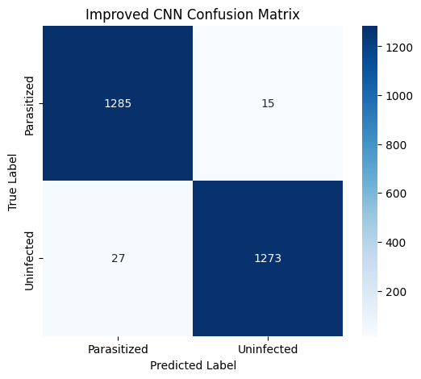

```python
# Compute confusion matrix

cm_model1 = confusion_matrix(
    model1_true_classes,
    model1_pred_classes
)

# Plot confusion matrix

plt.figure(figsize=(6,5))

sns.heatmap(
    cm_model1,
    annot=True,
    fmt="d",
    cmap="Blues",
    xticklabels=["Parasitized","Uninfected"],
    yticklabels=["Parasitized","Uninfected"]
)

plt.xlabel("Predicted Label")
plt.ylabel("True Label")
plt.title("Improved CNN Confusion Matrix")

plt.show()
```

```python
print(
    classification_report(
        model1_true_classes,
        model1_pred_classes,
        target_names=["Parasitized","Uninfected"]
    )
)
```

```
              precision    recall  f1-score   support

 Parasitized       0.98      0.99      0.98      1300
  Uninfected       0.99      0.98      0.98      1300

    accuracy                           0.98      2600
   macro avg       0.98      0.98      0.98      2600
weighted avg       0.98      0.98      0.98      2600
```

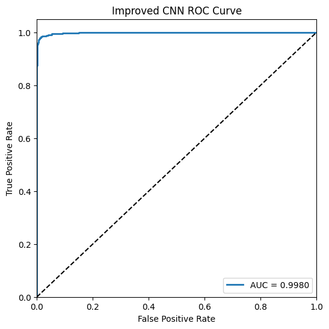

```
AUC = 0.9980
```

```python
# ============================
# ROC Curve and AUC
# Improved CNN
# ============================

from sklearn.metrics import roc_curve, auc
import matplotlib.pyplot as plt

# Probability for the positive class (Parasitized)
model1_probs = model1_predictions[:, 1]

# Compute ROC curve
fpr, tpr, thresholds = roc_curve(
    model1_true_classes,
    model1_probs
)

# Compute AUC
roc_auc = auc(fpr, tpr)

# Plot ROC curve
plt.figure(figsize=(6,6))

plt.plot(
    fpr,
    tpr,
    linewidth=2,
    label=f"AUC = {roc_auc:.4f}"
)

plt.plot(
    [0,1],
    [0,1],
    'k--'
)

plt.xlim([0,1])
plt.ylim([0,1.05])

plt.xlabel("False Positive Rate")
plt.ylabel("True Positive Rate")
plt.title("Improved CNN ROC Curve")
plt.legend(loc="lower right")

plt.show()

print(f"AUC = {roc_auc:.4f}")
```

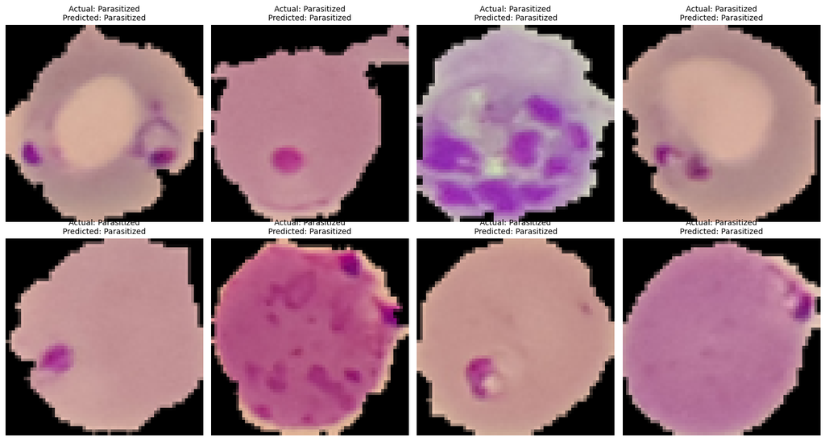

```python
correct_idx = np.where(
    model1_pred_classes == model1_true_classes
)[0]

plt.figure(figsize=(15,8))

for i in range(8):

    idx = correct_idx[i]

    plt.subplot(2,4,i+1)

    plt.imshow(test_images[idx])

    plt.title(
        f"Actual: {'Parasitized' if model1_true_classes[idx]==1 else 'Uninfected'}\n"
        f"Predicted: {'Parasitized' if model1_pred_classes[idx]==1 else 'Uninfected'}",
        fontsize=10
    )

    plt.axis("off")

plt.tight_layout()

plt.show()
```

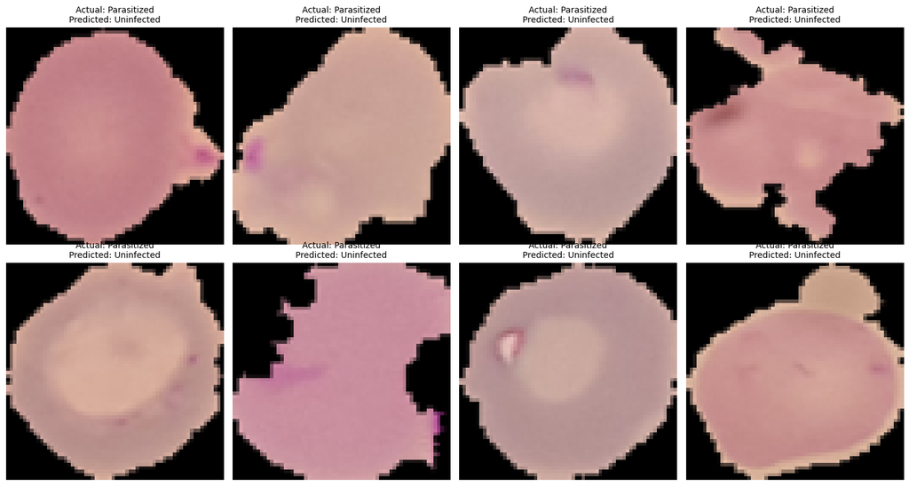

```python
incorrect_idx = np.where(
    model1_pred_classes != model1_true_classes
)[0]

plt.figure(figsize=(15,8))

n_images = min(8,len(incorrect_idx))

for i in range(n_images):

    idx = incorrect_idx[i]

    plt.subplot(2,4,i+1)

    plt.imshow(test_images[idx])

    plt.title(
        f"Actual: {'Parasitized' if model1_true_classes[idx]==1 else 'Uninfected'}\n"
        f"Predicted: {'Parasitized' if model1_pred_classes[idx]==1 else 'Uninfected'}",
        fontsize=10
    )

    plt.axis("off")

plt.tight_layout()

plt.show()
```

## **Observations and Insights**

The classification report further demonstrated excellent predictive performance, with **precision, recall, and F1-scores of approximately 0.98 for both classes**, indicating balanced classification accuracy without favoring one class over the other.

# **8. CNN with Batch Normalization and LeakyReLU**

## **Objective**

Although the improved CNN substantially enhanced predictive performance, additional architectural modifications may further improve model stability and generalization. One common approach is the incorporation of **Batch Normalization**, which stabilizes and accelerates training by normalizing intermediate feature maps. Another widely used enhancement is replacing the standard Rectified Linear Unit (ReLU) activation function with **LeakyReLU**, which reduces the risk of inactive ("dead") neurons by allowing a small gradient for negative input values.

The objective of this section is to develop a CNN incorporating Batch Normalization and LeakyReLU activation functions and evaluate whether these architectural enhancements further improve malaria image classification performance compared with both the baseline CNN and the improved CNN.

The architecture includes:

- Three convolutional blocks
- Batch Normalization after each convolution
- LeakyReLU activation
- Max-pooling layers
- Dropout regularization
- Softmax output layer

```python
from tensorflow.keras.layers import BatchNormalization, LeakyReLU
from tensorflow.keras import backend

backend.clear_session()

np.random.seed(42)
tf.random.set_seed(42)

model2 = Sequential([

    Conv2D(32,(3,3),padding="same",input_shape=(64,64,3)),
    BatchNormalization(),
    LeakyReLU(alpha=0.1),
    MaxPooling2D((2,2)),

    Conv2D(64,(3,3),padding="same"),
    BatchNormalization(),
    LeakyReLU(alpha=0.1),
    MaxPooling2D((2,2)),

    Conv2D(128,(3,3),padding="same"),
    BatchNormalization(),
    LeakyReLU(alpha=0.1),
    MaxPooling2D((2,2)),

    Flatten(),

    Dense(128),
    LeakyReLU(alpha=0.1),

    Dropout(0.5),

    Dense(2,activation="softmax")

])

model2.summary()
```

```
Model: "sequential"
```

```
┏━━━━━━━━━━━━━━━━━━━━━━━━━━━━━━━━━┳━━━━━━━━━━━━━━━━━━━━━━━━┳━━━━━━━━━━━━━━━┓
┃ Layer (type)                    ┃ Output Shape           ┃       Param # ┃
┡━━━━━━━━━━━━━━━━━━━━━━━━━━━━━━━━━╇━━━━━━━━━━━━━━━━━━━━━━━━╇━━━━━━━━━━━━━━━┩
│ conv2d (Conv2D)                 │ (None, 64, 64, 32)     │           896 │
├─────────────────────────────────┼────────────────────────┼───────────────┤
│ batch_normalization             │ (None, 64, 64, 32)     │           128 │
│ (BatchNormalization)            │                        │               │
├─────────────────────────────────┼────────────────────────┼───────────────┤
│ leaky_re_lu (LeakyReLU)         │ (None, 64, 64, 32)     │             0 │
├─────────────────────────────────┼────────────────────────┼───────────────┤
│ max_pooling2d (MaxPooling2D)    │ (None, 32, 32, 32)     │             0 │
├─────────────────────────────────┼────────────────────────┼───────────────┤
│ conv2d_1 (Conv2D)               │ (None, 32, 32, 64)     │        18,496 │
├─────────────────────────────────┼────────────────────────┼───────────────┤
│ batch_normalization_1           │ (None, 32, 32, 64)     │           256 │
│ (BatchNormalization)            │                        │               │
├─────────────────────────────────┼────────────────────────┼───────────────┤
│ leaky_re_lu_1 (LeakyReLU)       │ (None, 32, 32, 64)     │             0 │
├─────────────────────────────────┼────────────────────────┼───────────────┤
│ max_pooling2d_1 (MaxPooling2D)  │ (None, 16, 16, 64)     │             0 │
├─────────────────────────────────┼────────────────────────┼───────────────┤
│ conv2d_2 (Conv2D)               │ (None, 16, 16, 128)    │        73,856 │
├─────────────────────────────────┼────────────────────────┼───────────────┤
│ batch_normalization_2           │ (None, 16, 16, 128)    │           512 │
│ (BatchNormalization)            │                        │               │
├─────────────────────────────────┼────────────────────────┼───────────────┤
│ leaky_re_lu_2 (LeakyReLU)       │ (None, 16, 16, 128)    │             0 │
├─────────────────────────────────┼────────────────────────┼───────────────┤
│ max_pooling2d_2 (MaxPooling2D)  │ (None, 8, 8, 128)      │             0 │
├─────────────────────────────────┼────────────────────────┼───────────────┤
│ flatten (Flatten)               │ (None, 8192)           │             0 │
├─────────────────────────────────┼────────────────────────┼───────────────┤
│ dense (Dense)                   │ (None, 128)            │     1,048,704 │
├─────────────────────────────────┼────────────────────────┼───────────────┤
│ leaky_re_lu_3 (LeakyReLU)       │ (None, 128)            │             0 │
├─────────────────────────────────┼────────────────────────┼───────────────┤
│ dropout (Dropout)               │ (None, 128)            │             0 │
├─────────────────────────────────┼────────────────────────┼───────────────┤
│ dense_1 (Dense)                 │ (None, 2)              │           258 │
└─────────────────────────────────┴────────────────────────┴───────────────┘
```

```
 Total params: 1,143,106 (4.36 MB)
```

```
 Trainable params: 1,142,658 (4.36 MB)
```

```
 Non-trainable params: 448 (1.75 KB)
```

```python
model2.compile(
    optimizer="adam",
    loss="categorical_crossentropy",
    metrics=["accuracy"]
)

print("Model compiled successfully.")
```

```
Model compiled successfully.
```

## **Model Training**

### **Objective**

The Batch Normalization and LeakyReLU CNN is trained using the same training dataset and hyperparameters used for the previous models to ensure a fair comparison. Maintaining identical training conditions allows any observed performance differences to be attributed primarily to the architectural enhancements rather than changes in the training procedure.

The model is trained using:

- Adam optimizer
- Categorical cross-entropy loss
- Batch size of 32
- 10 training epochs
- 20% validation split

Training and validation accuracy and loss are monitored throughout the learning process to evaluate convergence and identify potential overfitting.

```python
history2 = model2.fit(
    train_images,
    train_labels,
    validation_split=0.20,
    epochs=10,
    batch_size=32,
    verbose=1
)
```

```
624/624 ━━━━━━━━━━━━━━━━━━━━ 282s 446ms/step - accuracy: 0.8498 - loss: 0.5046 - val_accuracy: 0.9683 - val_loss: 0.0974
624/624 ━━━━━━━━━━━━━━━━━━━━ 317s 439ms/step - accuracy: 0.9611 - loss: 0.1279 - val_accuracy: 0.9663 - val_loss: 0.1018
624/624 ━━━━━━━━━━━━━━━━━━━━ 326s 445ms/step - accuracy: 0.9699 - loss: 0.1008 - val_accuracy: 0.9756 - val_loss: 0.0702
624/624 ━━━━━━━━━━━━━━━━━━━━ 277s 444ms/step - accuracy: 0.9744 - loss: 0.0837 - val_accuracy: 0.9708 - val_loss: 0.1263
624/624 ━━━━━━━━━━━━━━━━━━━━ 323s 446ms/step - accuracy: 0.9748 - loss: 0.0748 - val_accuracy: 0.9734 - val_loss: 0.1214
624/624 ━━━━━━━━━━━━━━━━━━━━ 274s 439ms/step - accuracy: 0.9749 - loss: 0.0740 - val_accuracy: 0.9788 - val_loss: 0.0696
624/624 ━━━━━━━━━━━━━━━━━━━━ 325s 444ms/step - accuracy: 0.9776 - loss: 0.0661 - val_accuracy: 0.9774 - val_loss: 0.0732
624/624 ━━━━━━━━━━━━━━━━━━━━ 275s 441ms/step - accuracy: 0.9777 - loss: 0.0622 - val_accuracy: 0.9688 - val_loss: 0.1062
624/624 ━━━━━━━━━━━━━━━━━━━━ 326s 447ms/step - accuracy: 0.9793 - loss: 0.0579 - val_accuracy: 0.9758 - val_loss: 0.0780
624/624 ━━━━━━━━━━━━━━━━━━━━ 321s 445ms/step - accuracy: 0.9806 - loss: 0.0543 - val_accuracy: 0.9790 - val_loss: 0.0651
```

## **Observations and Insights**

Overall, the model showed strong learning performance with no substantial evidence of overfitting. The next step is to evaluate the model on the independent testing dataset and compare its performance with the baseline and improved CNN models.

## **Batch Normalization and LeakyReLU Evaluation**

### **Objective**

Following training, the Batch Normalization and LeakyReLU CNN is evaluated using the independent testing dataset to determine whether these architectural enhancements improved predictive performance and generalization compared with the previous CNN models.

The evaluation includes:

- Overall testing loss and classification accuracy
- Generation of predicted class labels
- Confusion matrix
- Classification report (precision, recall, and F1-score)
- ROC curve and Area Under the Curve (AUC)
- Visualization of correctly classified images
- Visualization of incorrectly classified images

```python
# Evaluate the Batch Normalization and LeakyReLU CNN on the independent testing dataset

model2_loss, model2_accuracy = model2.evaluate(
    test_images,
    test_labels,
    verbose=1
)

print(f"\nTest Loss: {model2_loss:.4f}")
print(f"Test Accuracy: {model2_accuracy * 100:.2f}%")
```

```
82/82 ━━━━━━━━━━━━━━━━━━━━ 7s 84ms/step - accuracy: 0.9781 - loss: 0.0673

Test Loss: 0.0673
Test Accuracy: 97.81%
```

```python
# Generate predicted probabilities

model2_predictions = model2.predict(test_images)

# Convert probabilities to predicted class labels

model2_pred_classes = np.argmax(model2_predictions, axis=1)

# Convert one-hot encoded labels back to class labels

model2_true_classes = np.argmax(test_labels, axis=1)

print("Predictions generated successfully.")
```

```
82/82 ━━━━━━━━━━━━━━━━━━━━ 10s 116ms/step
Predictions generated successfully.
```

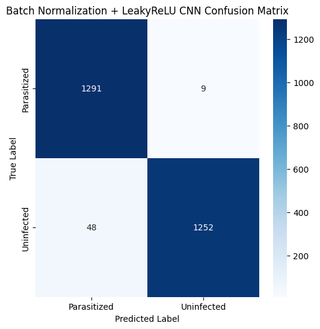

```python
from sklearn.metrics import confusion_matrix
import seaborn as sns

cm_model2 = confusion_matrix(
    model2_true_classes,
    model2_pred_classes
)

plt.figure(figsize=(6,6))

sns.heatmap(
    cm_model2,
    annot=True,
    fmt="d",
    cmap="Blues",
    xticklabels=["Parasitized","Uninfected"],
    yticklabels=["Parasitized","Uninfected"]
)

plt.xlabel("Predicted Label")
plt.ylabel("True Label")
plt.title("Batch Normalization + LeakyReLU CNN Confusion Matrix")

plt.show()
```

```python
from sklearn.metrics import classification_report

print(
    classification_report(
        model2_true_classes,
        model2_pred_classes,
        target_names=["Parasitized","Uninfected"]
    )
)
```

```
              precision    recall  f1-score   support

 Parasitized       0.96      0.99      0.98      1300
  Uninfected       0.99      0.96      0.98      1300

    accuracy                           0.98      2600
   macro avg       0.98      0.98      0.98      2600
weighted avg       0.98      0.98      0.98      2600
```

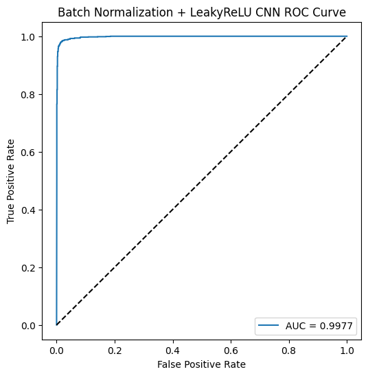

```python
from sklearn.metrics import roc_curve, auc

fpr, tpr, thresholds = roc_curve(
    model2_true_classes,
    model2_predictions[:,1]
)

roc_auc = auc(fpr, tpr)

plt.figure(figsize=(6,6))

plt.plot(
    fpr,
    tpr,
    label=f"AUC = {roc_auc:.4f}"
)

plt.plot([0,1],[0,1],"k--")

plt.xlabel("False Positive Rate")
plt.ylabel("True Positive Rate")
plt.title("Batch Normalization + LeakyReLU CNN ROC Curve")

plt.legend()

plt.show()
```

[figure not shown]

```python
correct_idx = np.where(
    model2_pred_classes == model2_true_classes
)[0]

plt.figure(figsize=(15, 8))

for i in range(8):
    idx = correct_idx[i]

    plt.subplot(2, 4, i+1)
    plt.imshow(test_images[idx])

    plt.title(
        f"Actual: {'Parasitized' if model2_true_classes[idx] == 0 else 'Uninfected'}\n"
        f"Predicted: {'Parasitized' if model2_pred_classes[idx] == 0 else 'Uninfected'}",
        fontsize=10
    )

    plt.axis("off")

plt.tight_layout()
plt.show()
```

[figure not shown]

```python
incorrect_idx = np.where(
    model2_pred_classes != model2_true_classes
)[0]

plt.figure(figsize=(15,8))

n_images = min(8,len(incorrect_idx))

for i in range(n_images):

    idx = incorrect_idx[i]

    plt.subplot(2,4,i+1)

    plt.imshow(test_images[idx])

    plt.title(
        f"Actual: {'Parasitized' if model2_true_classes[idx]==0 else 'Uninfected'}\n"
        f"Predicted: {'Parasitized' if model2_pred_classes[idx]==0 else 'Uninfected'}",
        fontsize=10
    )

    plt.axis("off")

plt.tight_layout()

plt.show()
```

## **Observations and Insights**

Although this model generalized well, its overall performance was slightly lower than that of the Improved CNN. These results suggest that incorporating Batch Normalization and LeakyReLU did not provide additional performance gains for this dataset. The next section investigates whether image augmentation can further improve model generalization and classification accuracy.

# **9. Image Augmentation CNN**

## **Objective**

Image augmentation artificially increases image diversity by applying small transformations such as rotation, zooming, shifting, and flipping. This can help the CNN generalize better by exposing it to realistic variations in blood smear images.

The objective of this section is to train a CNN using augmented images and compare its performance with the baseline, improved CNN, and Batch Normalization + LeakyReLU models.

```python
from sklearn.model_selection import train_test_split
from tensorflow.keras.preprocessing.image import ImageDataGenerator
from tensorflow.keras import backend

backend.clear_session()

np.random.seed(42)
tf.random.set_seed(42)

X_train, X_val, y_train, y_val = train_test_split(
    train_images,
    train_labels,
    test_size=0.20,
    random_state=42,
    stratify=train_labels
)

train_datagen = ImageDataGenerator(
    rotation_range=20,
    zoom_range=0.2,
    width_shift_range=0.1,
    height_shift_range=0.1,
    horizontal_flip=True
)

val_datagen = ImageDataGenerator()

train_generator = train_datagen.flow(
    X_train,
    y_train,
    batch_size=32,
    seed=42,
    shuffle=True
)

val_generator = val_datagen.flow(
    X_val,
    y_val,
    batch_size=32,
    seed=42,
    shuffle=False
)

print("Image augmentation generators created successfully.")
```

```
Image augmentation generators created successfully.
```

```python
from tensorflow.keras.models import Sequential
from tensorflow.keras.layers import Conv2D, MaxPooling2D, Flatten, Dense, Dropout

model3 = Sequential([

    Conv2D(32, (3,3), activation="relu", input_shape=(64,64,3)),
    MaxPooling2D(pool_size=(2,2)),

    Conv2D(64, (3,3), activation="relu"),
    MaxPooling2D(pool_size=(2,2)),

    Conv2D(128, (3,3), activation="relu"),
    MaxPooling2D(pool_size=(2,2)),

    Flatten(),

    Dense(128, activation="relu"),
    Dropout(0.5),

    Dense(2, activation="softmax")
])

model3.summary()
```

```
Model: "sequential"
```

```
┏━━━━━━━━━━━━━━━━━━━━━━━━━━━━━━━━━┳━━━━━━━━━━━━━━━━━━━━━━━━┳━━━━━━━━━━━━━━━┓
┃ Layer (type)                    ┃ Output Shape           ┃       Param # ┃
┡━━━━━━━━━━━━━━━━━━━━━━━━━━━━━━━━━╇━━━━━━━━━━━━━━━━━━━━━━━━╇━━━━━━━━━━━━━━━┩
│ conv2d (Conv2D)                 │ (None, 62, 62, 32)     │           896 │
├─────────────────────────────────┼────────────────────────┼───────────────┤
│ max_pooling2d (MaxPooling2D)    │ (None, 31, 31, 32)     │             0 │
├─────────────────────────────────┼────────────────────────┼───────────────┤
│ conv2d_1 (Conv2D)               │ (None, 29, 29, 64)     │        18,496 │
├─────────────────────────────────┼────────────────────────┼───────────────┤
│ max_pooling2d_1 (MaxPooling2D)  │ (None, 14, 14, 64)     │             0 │
├─────────────────────────────────┼────────────────────────┼───────────────┤
│ conv2d_2 (Conv2D)               │ (None, 12, 12, 128)    │        73,856 │
├─────────────────────────────────┼────────────────────────┼───────────────┤
│ max_pooling2d_2 (MaxPooling2D)  │ (None, 6, 6, 128)      │             0 │
├─────────────────────────────────┼────────────────────────┼───────────────┤
│ flatten (Flatten)               │ (None, 4608)           │             0 │
├─────────────────────────────────┼────────────────────────┼───────────────┤
│ dense (Dense)                   │ (None, 128)            │       589,952 │
├─────────────────────────────────┼────────────────────────┼───────────────┤
│ dropout (Dropout)               │ (None, 128)            │             0 │
├─────────────────────────────────┼────────────────────────┼───────────────┤
│ dense_1 (Dense)                 │ (None, 2)              │           258 │
└─────────────────────────────────┴────────────────────────┴───────────────┘
```

```
 Total params: 683,458 (2.61 MB)
```

```
 Trainable params: 683,458 (2.61 MB)
```

```
 Non-trainable params: 0 (0.00 B)
```

```python
model3.compile(
    optimizer="adam",
    loss="categorical_crossentropy",
    metrics=["accuracy"]
)

print("Model compiled successfully.")
```

```
Model compiled successfully.
```

## **Model Training**

### **Objective**

The CNN is trained using image augmentation to expose the model to realistic variations of the training images. During each training epoch, random transformations are applied to improve model robustness and reduce overfitting while keeping the validation dataset unchanged for unbiased performance assessment.

```python
history3 = model3.fit(
    train_generator,
    validation_data=val_generator,
    epochs=10,
    verbose=1
)
```

```
624/624 ━━━━━━━━━━━━━━━━━━━━ 195s 309ms/step - accuracy: 0.8303 - loss: 0.3415 - val_accuracy: 0.9688 - val_loss: 0.0944
624/624 ━━━━━━━━━━━━━━━━━━━━ 181s 290ms/step - accuracy: 0.9609 - loss: 0.1278 - val_accuracy: 0.9780 - val_loss: 0.0767
624/624 ━━━━━━━━━━━━━━━━━━━━ 177s 284ms/step - accuracy: 0.9643 - loss: 0.1148 - val_accuracy: 0.9774 - val_loss: 0.0806
624/624 ━━━━━━━━━━━━━━━━━━━━ 177s 283ms/step - accuracy: 0.9673 - loss: 0.1039 - val_accuracy: 0.9778 - val_loss: 0.0651
624/624 ━━━━━━━━━━━━━━━━━━━━ 176s 282ms/step - accuracy: 0.9691 - loss: 0.0979 - val_accuracy: 0.9782 - val_loss: 0.0630
624/624 ━━━━━━━━━━━━━━━━━━━━ 178s 286ms/step - accuracy: 0.9702 - loss: 0.0931 - val_accuracy: 0.9780 - val_loss: 0.0653
624/624 ━━━━━━━━━━━━━━━━━━━━ 201s 285ms/step - accuracy: 0.9719 - loss: 0.0869 - val_accuracy: 0.9792 - val_loss: 0.0663
624/624 ━━━━━━━━━━━━━━━━━━━━ 177s 284ms/step - accuracy: 0.9718 - loss: 0.0896 - val_accuracy: 0.9792 - val_loss: 0.0679
624/624 ━━━━━━━━━━━━━━━━━━━━ 176s 282ms/step - accuracy: 0.9710 - loss: 0.0905 - val_accuracy: 0.9782 - val_loss: 0.0659
624/624 ━━━━━━━━━━━━━━━━━━━━ 177s 283ms/step - accuracy: 0.9719 - loss: 0.0872 - val_accuracy: 0.9782 - val_loss: 0.0620
```

## **Observations and Insights**

The CNN trained with image augmentation demonstrated stable learning across all training epochs. Although the training accuracy was slightly lower than previous models because new image transformations were introduced during each epoch, the validation accuracy remained consistently high at approximately **98%**, indicating good generalization.

Overall, image augmentation improved the model's robustness by exposing it to realistic variations of the training images while maintaining strong validation performance. The next step is to evaluate the model on the independent testing dataset and compare its performance with the previously developed CNN architectures.

## **Image Augmentation CNN Evaluation**

### **Objective**

Following training, the Image Augmentation CNN is evaluated using the independent testing dataset to determine whether augmented training images improved predictive performance and generalization compared with the previous CNN models.

The evaluation includes:

- Overall testing loss and classification accuracy
- Generation of predicted class labels
- Confusion matrix
- Classification report (precision, recall, and F1-score)
- ROC curve and Area Under the Curve (AUC)
- Visualization of correctly classified images
- Visualization of incorrectly classified images

```python
# Evaluate the Image Augmentation CNN on the independent testing dataset

model3_loss, model3_accuracy = model3.evaluate(
    test_images,
    test_labels,
    verbose=1
)

print(f"\nTest Loss: {model3_loss:.4f}")
print(f"Test Accuracy: {model3_accuracy * 100:.2f}%")
```

```
82/82 ━━━━━━━━━━━━━━━━━━━━ 7s 82ms/step - accuracy: 0.9877 - loss: 0.0411

Test Loss: 0.0411
Test Accuracy: 98.77%
```

```python
# Generate predicted probabilities

model3_predictions = model3.predict(test_images)

# Convert probabilities to predicted class labels

model3_pred_classes = np.argmax(model3_predictions, axis=1)

# Convert one-hot encoded labels back to class labels

model3_true_classes = np.argmax(test_labels, axis=1)

print("Predictions generated successfully.")
```

```
82/82 ━━━━━━━━━━━━━━━━━━━━ 5s 57ms/step
Predictions generated successfully.
```

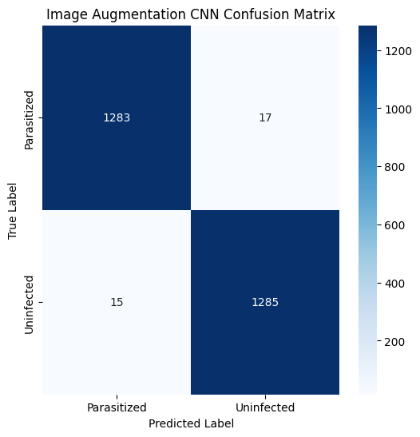

```python
cm_model3 = confusion_matrix(
    model3_true_classes,
    model3_pred_classes
)

plt.figure(figsize=(6,6))

sns.heatmap(
    cm_model3,
    annot=True,
    fmt="d",
    cmap="Blues",
    xticklabels=["Parasitized","Uninfected"],
    yticklabels=["Parasitized","Uninfected"]
)

plt.xlabel("Predicted Label")
plt.ylabel("True Label")
plt.title("Image Augmentation CNN Confusion Matrix")

plt.show()
```

```python
print(
    classification_report(
        model3_true_classes,
        model3_pred_classes,
        target_names=["Parasitized","Uninfected"]
    )
)
```

```
              precision    recall  f1-score   support

 Parasitized       0.99      0.99      0.99      1300
  Uninfected       0.99      0.99      0.99      1300

    accuracy                           0.99      2600
   macro avg       0.99      0.99      0.99      2600
weighted avg       0.99      0.99      0.99      2600
```

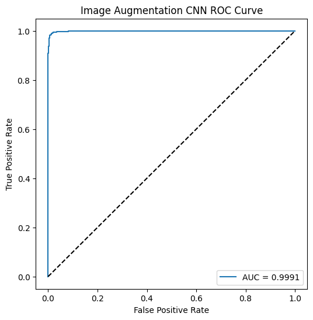

```python
fpr, tpr, thresholds = roc_curve(
    model3_true_classes,
    model3_predictions[:,1]
)

roc_auc = auc(fpr, tpr)

plt.figure(figsize=(6,6))

plt.plot(
    fpr,
    tpr,
    label=f"AUC = {roc_auc:.4f}"
)

plt.plot([0,1],[0,1],"k--")

plt.xlabel("False Positive Rate")
plt.ylabel("True Positive Rate")
plt.title("Image Augmentation CNN ROC Curve")

plt.legend()

plt.show()
```

[figure not shown]

```python
correct_idx = np.where(
    model3_pred_classes == model3_true_classes
)[0]

plt.figure(figsize=(15,8))

for i in range(8):

    idx = correct_idx[i]

    plt.subplot(2,4,i+1)

    plt.imshow(test_images[idx])

    plt.title(
        f"Actual: {'Parasitized' if model3_true_classes[idx]==0 else 'Uninfected'}\n"
        f"Predicted: {'Parasitized' if model3_pred_classes[idx]==0 else 'Uninfected'}",
        fontsize=10
    )

    plt.axis("off")

plt.tight_layout()

plt.show()
```

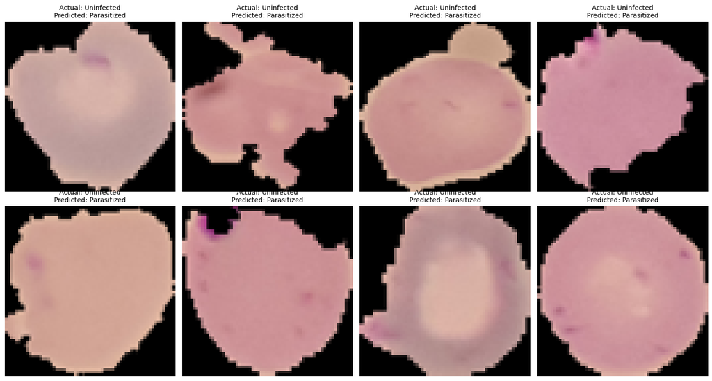

```python
incorrect_idx = np.where(
    model3_pred_classes != model3_true_classes
)[0]

plt.figure(figsize=(15,8))

n_images = min(8, len(incorrect_idx))

for i in range(n_images):

    idx = incorrect_idx[i]

    plt.subplot(2,4,i+1)

    plt.imshow(test_images[idx])

    plt.title(
        f"Actual: {'Parasitized' if model3_true_classes[idx]==0 else 'Uninfected'}\n"
        f"Predicted: {'Parasitized' if model3_pred_classes[idx]==0 else 'Uninfected'}",
        fontsize=10
    )

    plt.axis("off")

plt.tight_layout()

plt.show()
```

## **Observations and Insights**

Visualization of correctly and incorrectly classified images showed that the model successfully identified the vast majority of blood smear images while making relatively few errors, primarily on visually challenging samples with subtle parasite features or ambiguous morphology. Overall, image augmentation substantially improved model robustness while maintaining excellent predictive performance.